# Final Project

```r
rm(list = ls())

library(DataComputing)
library(dplyr)
library(lubridate)
library(mosaic)
library(tidyverse)
library(party)
```

## Purpose

**The purpose of this project is to observe the median salaries and salary percentiles for each major in various colleges, as well as other variables, in order to understand the overall cost and benefits of a college degree and how one can get the most of our education.**

## Imported Data

```r
degrees_that_pay_back <- read.csv(file = file.choose(), stringsAsFactors = F)
salaries_by_college_type <- read.csv(file = file.choose(), stringsAsFactors = F)
salaries_by_region <- read.csv(file = file.choose(), stringsAsFactors = F)
```

## Data Intake

```r
degrees_that_pay_back %>%
  head(20)
```

|  | Undergraduate.Major | Starting.Median.Salary | Mid.Career.Median.Salary | Percent.change.from.Starting.to.Mid.Career.Salary | Mid.Career.10th.Percentile.Salary | Mid.Career.25th.Percentile.Salary | Mid.Career.75th.Percentile.Salary | Mid.Career.90th.Percentile.Salary |
| --- | --- | --- | --- | --- | --- | --- | --- | --- |
| 1 | Accounting | $46,000.00 | $77,100.00 | 67.6 | $42,200.00 | $56,100.00 | $108,000.00 | $152,000.00 |
| 2 | Aerospace Engineering | $57,700.00 | $101,000.00 | 75.0 | $64,300.00 | $82,100.00 | $127,000.00 | $161,000.00 |
| 3 | Agriculture | $42,600.00 | $71,900.00 | 68.8 | $36,300.00 | $52,100.00 | $96,300.00 | $150,000.00 |
| 4 | Anthropology | $36,800.00 | $61,500.00 | 67.1 | $33,800.00 | $45,500.00 | $89,300.00 | $138,000.00 |
| 5 | Architecture | $41,600.00 | $76,800.00 | 84.6 | $50,600.00 | $62,200.00 | $97,000.00 | $136,000.00 |
| 6 | Art History | $35,800.00 | $64,900.00 | 81.3 | $28,800.00 | $42,200.00 | $87,400.00 | $125,000.00 |
| 7 | Biology | $38,800.00 | $64,800.00 | 67.0 | $36,900.00 | $47,400.00 | $94,500.00 | $135,000.00 |
| 8 | Business Management | $43,000.00 | $72,100.00 | 67.7 | $38,800.00 | $51,500.00 | $102,000.00 | $147,000.00 |
| 9 | Chemical Engineering | $63,200.00 | $107,000.00 | 69.3 | $71,900.00 | $87,300.00 | $143,000.00 | $194,000.00 |
| 10 | Chemistry | $42,600.00 | $79,900.00 | 87.6 | $45,300.00 | $60,700.00 | $108,000.00 | $148,000.00 |

[output cut: 10 more lines]

```r
salaries_by_college_type %>%
  head(20)
```

|  | School.Name | School.Type | Starting.Median.Salary | Mid.Career.Median.Salary | Mid.Career.10th.Percentile.Salary | Mid.Career.25th.Percentile.Salary | Mid.Career.75th.Percentile.Salary | Mid.Career.90th.Percentile.Salary |
| --- | --- | --- | --- | --- | --- | --- | --- | --- |
| 1 | Massachusetts Institute of Technology (MIT) | Engineering | $72,200.00 | $126,000.00 | $76,800.00 | $99,200.00 | $168,000.00 | $220,000.00 |
| 2 | California Institute of Technology (CIT) | Engineering | $75,500.00 | $123,000.00 | N/A | $104,000.00 | $161,000.00 | N/A |
| 3 | Harvey Mudd College | Engineering | $71,800.00 | $122,000.00 | N/A | $96,000.00 | $180,000.00 | N/A |
| 4 | Polytechnic University of New York, Brooklyn | Engineering | $62,400.00 | $114,000.00 | $66,800.00 | $94,300.00 | $143,000.00 | $190,000.00 |
| 5 | Cooper Union | Engineering | $62,200.00 | $114,000.00 | N/A | $80,200.00 | $142,000.00 | N/A |
| 6 | Worcester Polytechnic Institute (WPI) | Engineering | $61,000.00 | $114,000.00 | $80,000.00 | $91,200.00 | $137,000.00 | $180,000.00 |
| 7 | Carnegie Mellon University (CMU) | Engineering | $61,800.00 | $111,000.00 | $63,300.00 | $80,100.00 | $150,000.00 | $209,000.00 |
| 8 | Rensselaer Polytechnic Institute (RPI) | Engineering | $61,100.00 | $110,000.00 | $71,600.00 | $85,500.00 | $140,000.00 | $182,000.00 |
| 9 | Georgia Institute of Technology | Engineering | $58,300.00 | $106,000.00 | $67,200.00 | $85,200.00 | $137,000.00 | $183,000.00 |
| 10 | Colorado School of Mines | Engineering | $58,100.00 | $106,000.00 | $62,200.00 | $87,900.00 | $142,000.00 | $201,000.00 |

[output cut: 10 more lines]

```r
salaries_by_region %>%
  head(20)
```

|  | School.Name | Region | Starting.Median.Salary | Mid.Career.Median.Salary | Mid.Career.10th.Percentile.Salary | Mid.Career.25th.Percentile.Salary | Mid.Career.75th.Percentile.Salary | Mid.Career.90th.Percentile.Salary |
| --- | --- | --- | --- | --- | --- | --- | --- | --- |
| 1 | Stanford University | California | $70,400.00 | $129,000.00 | $68,400.00 | $93,100.00 | $184,000.00 | $257,000.00 |
| 2 | California Institute of Technology (CIT) | California | $75,500.00 | $123,000.00 | N/A | $104,000.00 | $161,000.00 | N/A |
| 3 | Harvey Mudd College | California | $71,800.00 | $122,000.00 | N/A | $96,000.00 | $180,000.00 | N/A |
| 4 | University of California, Berkeley | California | $59,900.00 | $112,000.00 | $59,500.00 | $81,000.00 | $149,000.00 | $201,000.00 |
| 5 | Occidental College | California | $51,900.00 | $105,000.00 | N/A | $54,800.00 | $157,000.00 | N/A |
| 6 | Cal Poly San Luis Obispo | California | $57,200.00 | $101,000.00 | $55,000.00 | $74,700.00 | $133,000.00 | $178,000.00 |
| 7 | University of California at Los Angeles (UCLA) | California | $52,600.00 | $101,000.00 | $51,300.00 | $72,500.00 | $139,000.00 | $193,000.00 |
| 8 | University of California, San Diego (UCSD) | California | $51,100.00 | $101,000.00 | $51,700.00 | $75,400.00 | $131,000.00 | $177,000.00 |
| 9 | Pomona College | California | $48,600.00 | $101,000.00 | N/A | $63,300.00 | $161,000.00 | N/A |
| 10 | University of Southern California (USC) | California | $54,800.00 | $99,600.00 | $49,700.00 | $73,800.00 | $140,000.00 | $201,000.00 |

[output cut: 10 more lines]

### Data Wrangling

We want to check which major produces the highest starting median salary from increasing order. This can be a good starting point to give us an idea of whether a major is well-paid or not.

```r
highest_starting_salary <-
  degrees_that_pay_back %>%
    group_by(Undergraduate.Major) %>%
    summarise(salary = Starting.Median.Salary) %>%
    arrange(desc(salary))

highest_starting_salary
```

| Undergraduate.Major | salary |
| --- | --- |
| Physician Assistant | $74,300.00 |
| Chemical Engineering | $63,200.00 |
| Computer Engineering | $61,400.00 |
| Electrical Engineering | $60,900.00 |
| Mechanical Engineering | $57,900.00 |
| Aerospace Engineering | $57,700.00 |
| Industrial Engineering | $57,700.00 |
| Computer Science | $55,900.00 |
| Nursing | $54,200.00 |
| Civil Engineering | $53,900.00 |

[output cut: 40 more lines]

It’s interesting to see which majors contribute to the highest starting median salary. But, would the major actually contributes to salary increases throughout a person’s career?

```r
highest_salary_increases <-
  degrees_that_pay_back %>%
    group_by(Undergraduate.Major) %>%

    summarise(difference = as.numeric(gsub('\\$|,', '', Mid.Career.Median.Salary)) - as.numeric(gsub('\\$|,', '', Starting.Median.Salary))) %>%

    spread(key = Undergraduate.Major, value = difference, fill=0)

highest_salary_increases
```

| Accounting | Aerospace Engineering | Agriculture | Anthropology | Architecture | Art History | Biology | Business Management | Chemical Engineering | Chemistry | Civil Engineering | Communications | Computer Engineering | Computer Science | Construction | Criminal Justice | Drama | Economics | Education | Electrical Engineering | English | Film | Finance | Forestry | Geography | Geology | Graphic Design | Health Care Administration | History | Hospitality & Tourism | … |
| --- | --- | --- | --- | --- | --- | --- | --- | --- | --- | --- | --- | --- | --- | --- | --- | --- | --- | --- | --- | --- | --- | --- | --- | --- | --- | --- | --- | --- | --- | --- |
| 31100 | 43300 | 29300 | 24700 | 35200 | 29100 | 26000 | 29100 | 43800 | 37300 | 36600 | 31900 | 43600 | 39600 | 35200 | 21300 | 21000 | 48500 | 17100 | 42100 | 26700 | 30600 | 40400 | 23500 | 24300 | 36000 | 24100 | 21800 | 31800 | 19700 | … |

Based on our findings, it seems like a major in Econimcs would produce the greatest salary increases with a total of $48,500, compared to the other majors. It’s also noticeable that Engineering majors are in the top 7 of this list.

So far, majors that are related to engineering show up in our previous findings. We want to look closely at this major and see if there are other indications that may suggest the idea that an engineering degree would contribute greatly to a person’s salary.

```r
engineering_salaries <-
  salaries_by_college_type %>%
    filter(grepl("Engineering", School.Type, ignore.case = TRUE)) %>%
    select(School.Name, Starting.Median.Salary, Mid.Career.Median.Salary)

engineering_salaries
```

| School.Name | Starting.Median.Salary | Mid.Career.Median.Salary |
| --- | --- | --- |
| Massachusetts Institute of Technology (MIT) | $72,200.00 | $126,000.00 |
| California Institute of Technology (CIT) | $75,500.00 | $123,000.00 |
| Harvey Mudd College | $71,800.00 | $122,000.00 |
| Polytechnic University of New York, Brooklyn | $62,400.00 | $114,000.00 |
| Cooper Union | $62,200.00 | $114,000.00 |
| Worcester Polytechnic Institute (WPI) | $61,000.00 | $114,000.00 |
| Carnegie Mellon University (CMU) | $61,800.00 | $111,000.00 |
| Rensselaer Polytechnic Institute (RPI) | $61,100.00 | $110,000.00 |
| Georgia Institute of Technology | $58,300.00 | $106,000.00 |
| Colorado School of Mines | $58,100.00 | $106,000.00 |

[output cut: 9 more lines]

Here, we use the ‘salaries_by_college_type’ data set and we filtered out all of the schools that are not an ‘Engineering’ type. While observing the starting and mid-career median salaries, it’s astonishing by how much money a person can earn if they’re a part of an engineering major or school.

Knowing that engineering majors generally produces more income for a person, one last thing that comes to mind is whether a college degree is even worth it.

```r
majors_with_lowest_salary <-
  degrees_that_pay_back %>%
    summarise(min(Starting.Median.Salary), max(Starting.Median.Salary))

majors_with_lowest_salary
```

| min(Starting.Median.Salary) | max(Starting.Median.Salary) |
| --- | --- |
| $34,000.00 | $74,300.00 |

It turns out that students generally earn between $34,000 - $75,000 once they graduate. One may question if whether or not this is worth it, given the amount of money a student has to pay in order to get his or her degree. We believe that there may be other factors involved that determines if a college degree is worth it or not.

Since engineering majors contribute the most to our salaries, We decided to look a bit deeper in our data and see if we can maximize our opportunity to make more money with our education.

```r
school_names <-
  salaries_by_college_type %>%
  select(School.Name, School.Type)

joined <-
  school_names %>%
  select(School.Name, School.Type) %>%
  left_join(salaries_by_region %>% select(School.Name, Region, Starting.Median.Salary),
            by = c("School.Name" = "School.Name"))

final_data <-
  joined %>%
    filter(School.Type == "Engineering") %>%
    group_by(School.Type, Region) %>%
    summarise(total=n())

final_data
```

| School.Type | Region | total |
| --- | --- | --- |
| Engineering | California | 2 |
| Engineering | Midwestern | 2 |
| Engineering | Northeastern | 9 |
| Engineering | Southern | 3 |
| Engineering | Western | 2 |
| Engineering | NA | 1 |

### Data Visualization

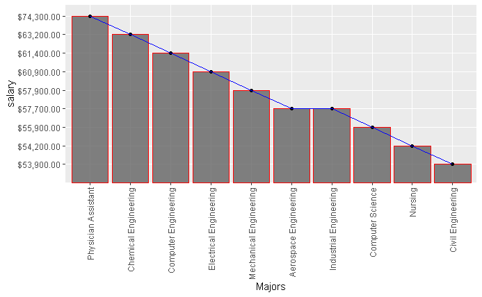

```r
highest_starting_salary %>%
  head(10) %>%
  ggplot(aes(x = reorder(Undergraduate.Major, desc(salary)), y = salary, group=1)) +
  xlab("Majors") +
  geom_bar(colour="red",stat='identity', alpha = 0.75, width=.9) +
  geom_point() + geom_line(color="blue") +
  theme(axis.text.x = element_text(angle = 90, hjust =1, vjust = 0.5))
```

A bar chart of the top 10 majors and their starting salaries.

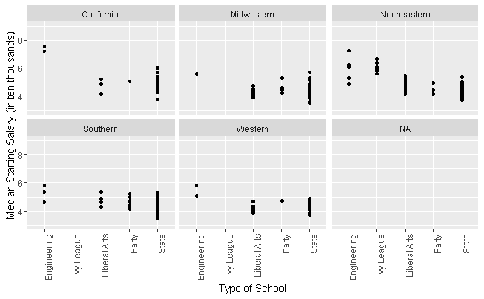

```r
joined %>%
  mutate(median = as.numeric(gsub('\\$|,', '', Starting.Median.Salary))/10000) %>%
  ggplot(aes(y=median,x=School.Type))+
  geom_point() +
  facet_wrap(~ Region) +
  theme(axis.text.x = element_text(angle = 90, hjust = 1)) +
  coord_cartesian(ylim=c(3, 9)) +
  ylab("Median Starting Salary (in ten thousands)") + xlab("Type of School")
```

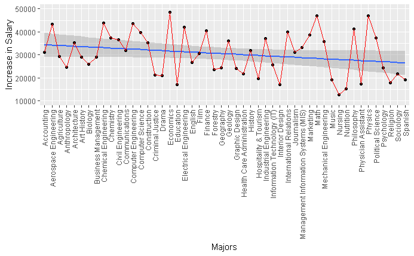

```r
difference <-
  degrees_that_pay_back %>%
    group_by(Undergraduate.Major) %>%
    summarise(difference = as.numeric(gsub('\\$|,', '', Mid.Career.Median.Salary)) - as.numeric(gsub('\\$|,', '', Starting.Median.Salary)))

difference %>%
  ggplot(aes(x = Undergraduate.Major, y = difference, group=2)) +
  stat_smooth(method=lm) +
  geom_point() +
  theme(axis.text.x = element_text(angle = 90, hjust = 1, vjust = 0.5)) +
  geom_line(color="red") +
  ylim(10000, 50000) +
  ylab("Increase in Salary") + xlab("Majors")
```

A line graph with a smoother line that shows the list of majors and their increase in salary (from starting salary to mid-career salary).